# Mercedes_Project_Final_Submission

```python
import numpy as np
import pandas as pd
import matplotlib.pyplot as plt
import seaborn as sns
import scipy.stats as stats
import math
from sklearn.preprocessing import LabelEncoder
from sklearn.linear_model import LinearRegression
from sklearn.metrics import r2_score
from sklearn.feature_selection import VarianceThreshold
plt.rcParams['figure.figsize'] = (10,10)
```

### **Step 1. Import Data File**

```python
merc_train_df = pd.read_csv('/home/labsuser/Datasets/merc_train.csv')
merc_train_df.shape
```

```
(4209, 378)
```

```python
merc_test_df = pd.read_csv('/home/labsuser/Datasets/merc_test.csv')
merc_test_df.shape
```

```
(4209, 377)
```

### **Step 2. Data Preprocessing**

**2.1 Check Top 5 Rows**

```python
merc_train_df.head()
```

|  | ID | y | X0 | X1 | X2 | X3 | X4 | X5 | X6 | X8 | ... | X375 | X376 | X377 | X378 | X379 | X380 | X382 | X383 | X384 | X385 |
| --- | --- | --- | --- | --- | --- | --- | --- | --- | --- | --- | --- | --- | --- | --- | --- | --- | --- | --- | --- | --- | --- |
| 0 | 0 | 130.81 | k | v | at | a | d | u | j | o | ... | 0 | 0 | 1 | 0 | 0 | 0 | 0 | 0 | 0 | 0 |
| 1 | 6 | 88.53 | k | t | av | e | d | y | l | o | ... | 1 | 0 | 0 | 0 | 0 | 0 | 0 | 0 | 0 | 0 |
| 2 | 7 | 76.26 | az | w | n | c | d | x | j | x | ... | 0 | 0 | 0 | 0 | 0 | 0 | 1 | 0 | 0 | 0 |
| 3 | 9 | 80.62 | az | t | n | f | d | x | l | e | ... | 0 | 0 | 0 | 0 | 0 | 0 | 0 | 0 | 0 | 0 |
| 4 | 13 | 78.02 | az | v | n | f | d | h | d | n | ... | 0 | 0 | 0 | 0 | 0 | 0 | 0 | 0 | 0 | 0 |

5 rows × 378 columns

```python
merc_test_df.head()
```

|  | ID | X0 | X1 | X2 | X3 | X4 | X5 | X6 | X8 | X10 | ... | X375 | X376 | X377 | X378 | X379 | X380 | X382 | X383 | X384 | X385 |
| --- | --- | --- | --- | --- | --- | --- | --- | --- | --- | --- | --- | --- | --- | --- | --- | --- | --- | --- | --- | --- | --- |
| 0 | 1 | az | v | n | f | d | t | a | w | 0 | ... | 0 | 0 | 0 | 1 | 0 | 0 | 0 | 0 | 0 | 0 |
| 1 | 2 | t | b | ai | a | d | b | g | y | 0 | ... | 0 | 0 | 1 | 0 | 0 | 0 | 0 | 0 | 0 | 0 |
| 2 | 3 | az | v | as | f | d | a | j | j | 0 | ... | 0 | 0 | 0 | 1 | 0 | 0 | 0 | 0 | 0 | 0 |
| 3 | 4 | az | l | n | f | d | z | l | n | 0 | ... | 0 | 0 | 0 | 1 | 0 | 0 | 0 | 0 | 0 | 0 |
| 4 | 5 | w | s | as | c | d | y | i | m | 0 | ... | 1 | 0 | 0 | 0 | 0 | 0 | 0 | 0 | 0 | 0 |

5 rows × 377 columns

**2.2 Check Data Stats**

```python
merc_train_df.describe()
```

|  | ID | y | X10 | X11 | X12 | X13 | X14 | X15 | X16 | X17 | ... | X375 | X376 | X377 | X378 | X379 | X380 | X382 | X383 | X384 | X385 |
| --- | --- | --- | --- | --- | --- | --- | --- | --- | --- | --- | --- | --- | --- | --- | --- | --- | --- | --- | --- | --- | --- |
| count | 4209.000000 | 4209.000000 | 4209.000000 | 4209.0 | 4209.000000 | 4209.000000 | 4209.000000 | 4209.000000 | 4209.000000 | 4209.000000 | ... | 4209.000000 | 4209.000000 | 4209.000000 | 4209.000000 | 4209.000000 | 4209.000000 | 4209.000000 | 4209.000000 | 4209.000000 | 4209.000000 |
| mean | 4205.960798 | 100.669318 | 0.013305 | 0.0 | 0.075077 | 0.057971 | 0.428130 | 0.000475 | 0.002613 | 0.007603 | ... | 0.318841 | 0.057258 | 0.314802 | 0.020670 | 0.009503 | 0.008078 | 0.007603 | 0.001663 | 0.000475 | 0.001426 |
| std | 2437.608688 | 12.679381 | 0.114590 | 0.0 | 0.263547 | 0.233716 | 0.494867 | 0.021796 | 0.051061 | 0.086872 | ... | 0.466082 | 0.232363 | 0.464492 | 0.142294 | 0.097033 | 0.089524 | 0.086872 | 0.040752 | 0.021796 | 0.037734 |
| min | 0.000000 | 72.110000 | 0.000000 | 0.0 | 0.000000 | 0.000000 | 0.000000 | 0.000000 | 0.000000 | 0.000000 | ... | 0.000000 | 0.000000 | 0.000000 | 0.000000 | 0.000000 | 0.000000 | 0.000000 | 0.000000 | 0.000000 | 0.000000 |
| 25% | 2095.000000 | 90.820000 | 0.000000 | 0.0 | 0.000000 | 0.000000 | 0.000000 | 0.000000 | 0.000000 | 0.000000 | ... | 0.000000 | 0.000000 | 0.000000 | 0.000000 | 0.000000 | 0.000000 | 0.000000 | 0.000000 | 0.000000 | 0.000000 |
| 50% | 4220.000000 | 99.150000 | 0.000000 | 0.0 | 0.000000 | 0.000000 | 0.000000 | 0.000000 | 0.000000 | 0.000000 | ... | 0.000000 | 0.000000 | 0.000000 | 0.000000 | 0.000000 | 0.000000 | 0.000000 | 0.000000 | 0.000000 | 0.000000 |
| 75% | 6314.000000 | 109.010000 | 0.000000 | 0.0 | 0.000000 | 0.000000 | 1.000000 | 0.000000 | 0.000000 | 0.000000 | ... | 1.000000 | 0.000000 | 1.000000 | 0.000000 | 0.000000 | 0.000000 | 0.000000 | 0.000000 | 0.000000 | 0.000000 |
| max | 8417.000000 | 265.320000 | 1.000000 | 0.0 | 1.000000 | 1.000000 | 1.000000 | 1.000000 | 1.000000 | 1.000000 | ... | 1.000000 | 1.000000 | 1.000000 | 1.000000 | 1.000000 | 1.000000 | 1.000000 | 1.000000 | 1.000000 | 1.000000 |

8 rows × 370 columns

```python
merc_test_df.describe()
```

|  | ID | X10 | X11 | X12 | X13 | X14 | X15 | X16 | X17 | X18 | ... | X375 | X376 | X377 | X378 | X379 | X380 | X382 | X383 | X384 | X385 |
| --- | --- | --- | --- | --- | --- | --- | --- | --- | --- | --- | --- | --- | --- | --- | --- | --- | --- | --- | --- | --- | --- |
| count | 4209.000000 | 4209.000000 | 4209.000000 | 4209.000000 | 4209.000000 | 4209.000000 | 4209.000000 | 4209.000000 | 4209.000000 | 4209.000000 | ... | 4209.000000 | 4209.000000 | 4209.000000 | 4209.000000 | 4209.000000 | 4209.000000 | 4209.000000 | 4209.000000 | 4209.000000 | 4209.000000 |
| mean | 4211.039202 | 0.019007 | 0.000238 | 0.074364 | 0.061060 | 0.427893 | 0.000713 | 0.002613 | 0.008791 | 0.010216 | ... | 0.325968 | 0.049656 | 0.311951 | 0.019244 | 0.011879 | 0.008078 | 0.008791 | 0.000475 | 0.000713 | 0.001663 |
| std | 2423.078926 | 0.136565 | 0.015414 | 0.262394 | 0.239468 | 0.494832 | 0.026691 | 0.051061 | 0.093357 | 0.100570 | ... | 0.468791 | 0.217258 | 0.463345 | 0.137399 | 0.108356 | 0.089524 | 0.093357 | 0.021796 | 0.026691 | 0.040752 |
| min | 1.000000 | 0.000000 | 0.000000 | 0.000000 | 0.000000 | 0.000000 | 0.000000 | 0.000000 | 0.000000 | 0.000000 | ... | 0.000000 | 0.000000 | 0.000000 | 0.000000 | 0.000000 | 0.000000 | 0.000000 | 0.000000 | 0.000000 | 0.000000 |
| 25% | 2115.000000 | 0.000000 | 0.000000 | 0.000000 | 0.000000 | 0.000000 | 0.000000 | 0.000000 | 0.000000 | 0.000000 | ... | 0.000000 | 0.000000 | 0.000000 | 0.000000 | 0.000000 | 0.000000 | 0.000000 | 0.000000 | 0.000000 | 0.000000 |
| 50% | 4202.000000 | 0.000000 | 0.000000 | 0.000000 | 0.000000 | 0.000000 | 0.000000 | 0.000000 | 0.000000 | 0.000000 | ... | 0.000000 | 0.000000 | 0.000000 | 0.000000 | 0.000000 | 0.000000 | 0.000000 | 0.000000 | 0.000000 | 0.000000 |
| 75% | 6310.000000 | 0.000000 | 0.000000 | 0.000000 | 0.000000 | 1.000000 | 0.000000 | 0.000000 | 0.000000 | 0.000000 | ... | 1.000000 | 0.000000 | 1.000000 | 0.000000 | 0.000000 | 0.000000 | 0.000000 | 0.000000 | 0.000000 | 0.000000 |
| max | 8416.000000 | 1.000000 | 1.000000 | 1.000000 | 1.000000 | 1.000000 | 1.000000 | 1.000000 | 1.000000 | 1.000000 | ... | 1.000000 | 1.000000 | 1.000000 | 1.000000 | 1.000000 | 1.000000 | 1.000000 | 1.000000 | 1.000000 | 1.000000 |

8 rows × 369 columns

**2.3 Check for Null Values**

```python
merc_train_df.isna().sum().sum()
#No Null Values Present in Train Data
```

```
0
```

```python
merc_test_df.isna().sum().sum()
#No Null Values Present in Test Data
```

```
0
```

**2.4 Check Data Distribution and Unique Values**

```python
# for col in merc_train_df.columns:
#     print("Unique values in {} Column are".format(col), merc_train_df[col].unique())
```

Training Data Observation with above command

- ID column is not useful as usual
- 8 Columns are Categorical Columns
- Most of the Numerical Columns has mix of 0's and 1's
- Few of the columns has values only 0's
- Target variable is continuous

```python
# for col in merc_test_df.columns:
#     print("Unique values in {} Column are".format(col), merc_test_df[col].unique())
```

Observations are same as above but Test Data doesn't have the Target Value

**2.5 Perform Label Encoding for Categorical Columns**

```python
merc_train_df_1 = merc_train_df.copy()
```

```python
df_dtypes = merc_train_df_1.dtypes.reset_index()
df_dtypes.columns=['count', 'dtype']
grpd_df = df_dtypes.groupby('dtype').aggregate('count').reset_index()
grpd_df
```

|  | dtype | count |
| --- | --- | --- |
| 0 | int64 | 369 |
| 1 | float64 | 1 |
| 2 | object | 8 |

```python
encoding_col_list = df_dtypes[df_dtypes.dtype==object]['count'].values
encoding_col_list
```

```
array(['X0', 'X1', 'X2', 'X3', 'X4', 'X5', 'X6', 'X8'], dtype=object)
```

```python
le = LabelEncoder()
```

```python
for column in encoding_col_list:
    merc_train_df_1[column] = le.fit_transform(merc_train_df_1[column])
    print("Training Data - Label Encoding for {} Completed Successfully".format(column))
```

```
Training Data - Label Encoding for X0 Completed Successfully
Training Data - Label Encoding for X1 Completed Successfully
Training Data - Label Encoding for X2 Completed Successfully
Training Data - Label Encoding for X3 Completed Successfully
Training Data - Label Encoding for X4 Completed Successfully
Training Data - Label Encoding for X5 Completed Successfully
Training Data - Label Encoding for X6 Completed Successfully
Training Data - Label Encoding for X8 Completed Successfully
```

```python
merc_train_df_1.head(3)
```

|  | ID | y | X0 | X1 | X2 | X3 | X4 | X5 | X6 | X8 | ... | X375 | X376 | X377 | X378 | X379 | X380 | X382 | X383 | X384 | X385 |
| --- | --- | --- | --- | --- | --- | --- | --- | --- | --- | --- | --- | --- | --- | --- | --- | --- | --- | --- | --- | --- | --- |
| 0 | 0 | 130.81 | 32 | 23 | 17 | 0 | 3 | 24 | 9 | 14 | ... | 0 | 0 | 1 | 0 | 0 | 0 | 0 | 0 | 0 | 0 |
| 1 | 6 | 88.53 | 32 | 21 | 19 | 4 | 3 | 28 | 11 | 14 | ... | 1 | 0 | 0 | 0 | 0 | 0 | 0 | 0 | 0 | 0 |
| 2 | 7 | 76.26 | 20 | 24 | 34 | 2 | 3 | 27 | 9 | 23 | ... | 0 | 0 | 0 | 0 | 0 | 0 | 1 | 0 | 0 | 0 |

3 rows × 378 columns

```python
merc_test_df_1 = merc_test_df.copy()
```

```python
for column in encoding_col_list:
    merc_test_df_1[column] = le.fit_transform(merc_test_df_1[column])
    print("Testing Data - Label Encoding for {} Completed Successfully".format(column))
```

```
Testing Data - Label Encoding for X0 Completed Successfully
Testing Data - Label Encoding for X1 Completed Successfully
Testing Data - Label Encoding for X2 Completed Successfully
Testing Data - Label Encoding for X3 Completed Successfully
Testing Data - Label Encoding for X4 Completed Successfully
Testing Data - Label Encoding for X5 Completed Successfully
Testing Data - Label Encoding for X6 Completed Successfully
Testing Data - Label Encoding for X8 Completed Successfully
```

```python
merc_test_df_1.head(3)
```

|  | ID | X0 | X1 | X2 | X3 | X4 | X5 | X6 | X8 | X10 | ... | X375 | X376 | X377 | X378 | X379 | X380 | X382 | X383 | X384 | X385 |
| --- | --- | --- | --- | --- | --- | --- | --- | --- | --- | --- | --- | --- | --- | --- | --- | --- | --- | --- | --- | --- | --- |
| 0 | 1 | 21 | 23 | 34 | 5 | 3 | 26 | 0 | 22 | 0 | ... | 0 | 0 | 0 | 1 | 0 | 0 | 0 | 0 | 0 | 0 |
| 1 | 2 | 42 | 3 | 8 | 0 | 3 | 9 | 6 | 24 | 0 | ... | 0 | 0 | 1 | 0 | 0 | 0 | 0 | 0 | 0 | 0 |
| 2 | 3 | 21 | 23 | 17 | 5 | 3 | 0 | 9 | 9 | 0 | ... | 0 | 0 | 0 | 1 | 0 | 0 | 0 | 0 | 0 | 0 |

3 rows × 377 columns

**2.6 Detect Outliers in the Data**

**2.6.1 Check Encoded Categorical Variables using boxplot**

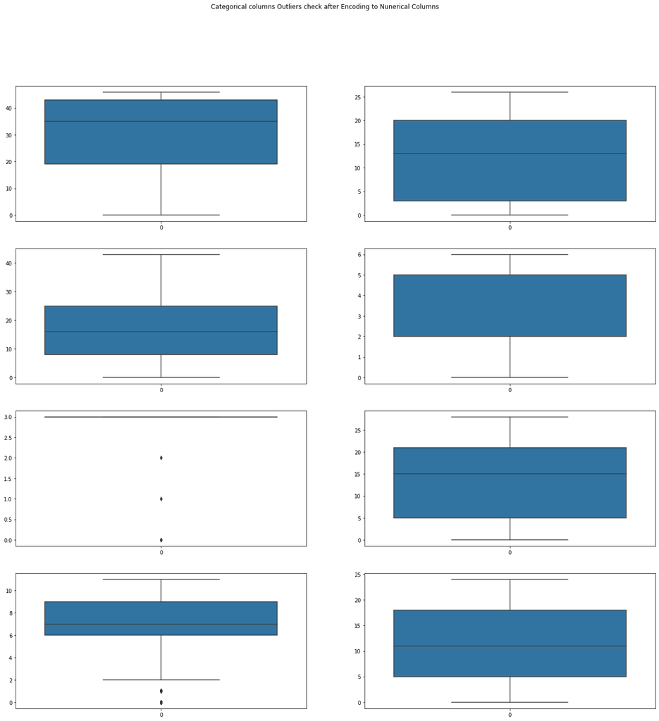

```python
fig, axes = plt.subplots(4, 2, figsize=(22, 22))
fig.suptitle('Categorical columns Outliers check after Encoding to Nunerical Columns')
sns.boxplot(ax=axes[0, 0], data = merc_train_df_1['X0'])
sns.boxplot(ax=axes[0, 1], data = merc_train_df_1['X1'])
sns.boxplot(ax=axes[1, 0], data = merc_train_df_1['X2'])
sns.boxplot(ax=axes[1, 1], data = merc_train_df_1['X3'])
sns.boxplot(ax=axes[2, 0], data = merc_train_df_1['X4'])
sns.boxplot(ax=axes[2, 1], data = merc_train_df_1['X5'])
sns.boxplot(ax=axes[3, 0], data = merc_train_df_1['X6'])
sns.boxplot(ax=axes[3, 1], data = merc_train_df_1['X8'])
```

```python
#Checking values for X4 column where outliers are observed
print(merc_train_df_1[merc_train_df_1['X4']==3].shape)
print(merc_train_df_1[merc_train_df_1['X4']<3].shape)
```

```
(4205, 378)
(4, 378)
```

```python
#Removing 4 Outliers Entries
merc_train_df_1 = merc_train_df_1[merc_train_df_1['X4']==3]
```

```python
#Checking values for X6 column where outliers are observed
print(merc_train_df_1[merc_train_df_1['X6']>=2].shape)
print(merc_train_df_1[merc_train_df_1['X6']<2].shape)
```

```
(3972, 378)
(233, 378)
```

```python
#Removing 233 Outiers Entries
merc_train_df_1 = merc_train_df_1[merc_train_df_1['X6']>=2]
```

```python
merc_train_df_1.shape
```

```
(3972, 378)
```

**2.6.2 Check Numerical Columns Distribution using bar graph**

```python
num_col_list = merc_train_df_1.iloc[:, 10:].columns
num_col_list
```

```
Index(['X10', 'X11', 'X12', 'X13', 'X14', 'X15', 'X16', 'X17', 'X18', 'X19',
       ...
       'X375', 'X376', 'X377', 'X378', 'X379', 'X380', 'X382', 'X383', 'X384',
       'X385'],
      dtype='object', length=368)
```

```python
zeroes_ones_dict = {}
for colname in num_col_list:
    zeroes = merc_train_df_1[merc_train_df_1[colname]==0].shape[0]
    ones = merc_train_df_1[merc_train_df_1[colname]==1].shape[0]
    zeroes_ones_dict[colname] = [zeroes, ones]
zeroes_ones_df = pd.DataFrame(zeroes_ones_dict)
zeroes_ones_df = zeroes_ones_df.T
zeroes_ones_df.columns = ['Zeroes', 'Ones']
zeroes_ones_df =  zeroes_ones_df.reset_index()
zeroes_ones_df
```

|  | index | Zeroes | Ones |
| --- | --- | --- | --- |
| 0 | X10 | 3916 | 56 |
| 1 | X11 | 3972 | 0 |
| 2 | X12 | 3683 | 289 |
| 3 | X13 | 3733 | 239 |
| 4 | X14 | 2224 | 1748 |
| ... | ... | ... | ... |
| 363 | X380 | 3939 | 33 |
| 364 | X382 | 3940 | 32 |
| 365 | X383 | 3966 | 6 |
| 366 | X384 | 3970 | 2 |
| 367 | X385 | 3967 | 5 |

368 rows × 3 columns

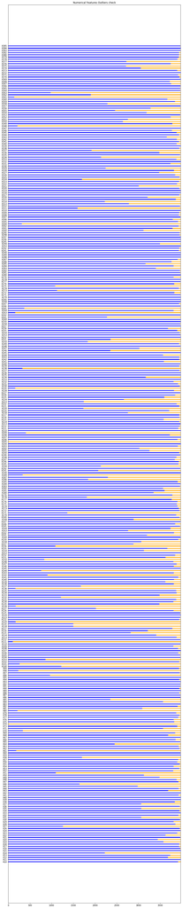

```python
width=0.3
plt.figure(figsize=(15,80))
plt.title('Numerical Features Outliers check')
plt.barh(zeroes_ones_df['index'], zeroes_ones_df.Zeroes, width, color='blue')
plt.barh(zeroes_ones_df['index'], zeroes_ones_df.Ones, width, left=zeroes_ones_df.Zeroes, color="orange")
plt.show()
```

**2.6.3 Remove Columns with Zero Variance**

```python
train_column_var = merc_train_df_1.var()
var_0_list = list(train_column_var[train_column_var==0.0].index)
var_0_list.append('ID')
var_0_list
```

```
['X4',
 'X11',
 'X93',
 'X107',
 'X233',
 'X235',
 'X268',
 'X270',
 'X289',
 'X290',
 'X293',
 'X297',
 'X330',
 'X347',
 'ID']
```

```python
merc_train_df_1.drop(var_0_list,axis=1,inplace=True)
```

```python
merc_train_df_1.shape
```

```
(3972, 363)
```

```python
merc_test_df_1.drop(var_0_list,axis=1,inplace=True)
```

```python
merc_test_df_1.shape
```

```
(4209, 362)
```

**2.6.4 Check Outliers in Dependent Variable**

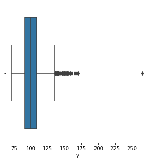

```python
plt.figure(figsize=(5,5))
sns.boxplot(merc_train_df_1['y'])
```

```python
def outlier_treatment(datacolumn):
    sorted(datacolumn)
    Q1,Q3 = np.percentile(datacolumn,[25,75])
    IQR = Q3-Q1
    lower_range = Q1 - (1.5*IQR)
    upper_range = Q3 + (1.5*IQR)
    return lower_range,upper_range
```

```python
l,u = outlier_treatment(merc_train_df_1['y'])
print(l)
print(u)
```

```
63.710000000000036
136.28999999999996
```

```python
merc_train_df_1[(merc_train_df_1['y'] > u) | (merc_train_df_1['y'] < l)].shape
```

```
(48, 363)
```

```python
#Removing the Outliers Observed
merc_train_df_1.drop(merc_train_df_1[(merc_train_df_1['y'] > u) | (merc_train_df_1['y'] < l)].index,inplace=True)
merc_train_df_1.shape
```

```
(3924, 363)
```

**2.7 Assign features (Independent) and target (Dependent) Variable**

**Train Data**

```python
merc_train_df_1.head(2)
```

|  | y | X0 | X1 | X2 | X3 | X5 | X6 | X8 | X10 | X12 | ... | X375 | X376 | X377 | X378 | X379 | X380 | X382 | X383 | X384 | X385 |
| --- | --- | --- | --- | --- | --- | --- | --- | --- | --- | --- | --- | --- | --- | --- | --- | --- | --- | --- | --- | --- | --- |
| 0 | 130.81 | 32 | 23 | 17 | 0 | 24 | 9 | 14 | 0 | 0 | ... | 0 | 0 | 1 | 0 | 0 | 0 | 0 | 0 | 0 | 0 |
| 1 | 88.53 | 32 | 21 | 19 | 4 | 28 | 11 | 14 | 0 | 0 | ... | 1 | 0 | 0 | 0 | 0 | 0 | 0 | 0 | 0 | 0 |

2 rows × 363 columns

```python
features = merc_train_df_1.drop('y',axis=1)
```

```python
features.shape
```

```
(3924, 362)
```

```python
target = merc_train_df_1['y']
target.shape
```

```
(3924,)
```

**Test Data**

```python
merc_test_df_1.head(2)
```

|  | X0 | X1 | X2 | X3 | X5 | X6 | X8 | X10 | X12 | X13 | ... | X375 | X376 | X377 | X378 | X379 | X380 | X382 | X383 | X384 | X385 |
| --- | --- | --- | --- | --- | --- | --- | --- | --- | --- | --- | --- | --- | --- | --- | --- | --- | --- | --- | --- | --- | --- |
| 0 | 21 | 23 | 34 | 5 | 26 | 0 | 22 | 0 | 0 | 0 | ... | 0 | 0 | 0 | 1 | 0 | 0 | 0 | 0 | 0 | 0 |
| 1 | 42 | 3 | 8 | 0 | 9 | 6 | 24 | 0 | 0 | 0 | ... | 0 | 0 | 1 | 0 | 0 | 0 | 0 | 0 | 0 | 0 |

2 rows × 362 columns

```python
features_test = merc_test_df_1.copy()
```

```python
features_test.shape
```

```
(4209, 362)
```

**2.8 Perform Train Test Split of the data**

```python
from sklearn.model_selection import train_test_split
```

```python
X_tr_train, X_tr_test, y_tr_train, y_tr_test = train_test_split(features,target, test_size=0.30, random_state=42)
```

```python
print(X_tr_train.shape)
print(X_tr_test.shape)
print(y_tr_train.shape)
print(y_tr_test.shape)
```

```
(2746, 362)
(1178, 362)
(2746,)
(1178,)
```

**2.9 Perform Standardization using Standard Scaler**

```python
from sklearn.preprocessing import StandardScaler
```

```python
scaler = StandardScaler()
```

**Train Data With Train Test Split**

```python
X_tr_train_scaled = scaler.fit_transform(X_tr_train)
```

```python
X_tr_test_scaled = scaler.fit_transform(X_tr_test)
```

```python
print(X_tr_train_scaled.shape)
print(X_tr_test_scaled.shape)
```

```
(2746, 362)
(1178, 362)
```

**Train Data Without Train Test Split**

```python
features_train_scaled = scaler.fit_transform(features)
features_train_scaled.shape
```

```
(3924, 362)
```

**Test Data**

```python
features_test_scaled = scaler.fit_transform(features_test)
features_test_scaled.shape
```

```
(4209, 362)
```

### **Step 3. Feature Engineering**

Applying Principal Component Analysis (PCA)

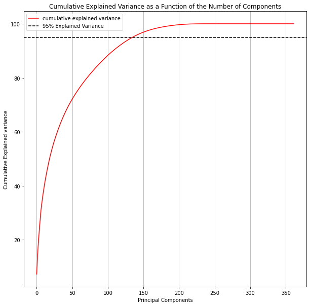

```python
from sklearn.decomposition import PCA
pca = PCA()
pca.fit(X_tr_train_scaled)
cumsum = np.cumsum(pca.explained_variance_ratio_)*100
d = [n for n in range(len(cumsum))]
plt.figure(figsize=(10, 10))
plt.plot(d,cumsum, color = 'red',label='cumulative explained variance')
plt.title('Cumulative Explained Variance as a Function of the Number of Components')
plt.ylabel('Cumulative Explained variance')
plt.grid(axis='x')
plt.xlabel('Principal Components')
plt.axhline(y = 95, color='k', linestyle='--', label = '95% Explained Variance')
plt.legend(loc='best')
```

```python
pca = PCA(n_components=0.95)
```

**Applying PCA for Train Data Split**

```python
pca.fit(X_tr_train_scaled)
```

```
PCA(copy=True, iterated_power='auto', n_components=0.95, random_state=None,
    svd_solver='auto', tol=0.0, whiten=False)
```

```python
pca.explained_variance_ratio_.size
```

```
136
```

**Train Data Transform - With Train Test Split**

```python
X_tr_train_pca = pca.transform(X_tr_train_scaled)
X_tr_train_pca.shape
```

```
(2746, 136)
```

```python
X_tr_test_pca = pca.transform(X_tr_test_scaled)
X_tr_test_pca.shape
```

```
(1178, 136)
```

**Test Data Transform**

```python
features_test_pca = pca.transform(features_test_scaled)
features_test_pca.shape
```

```
(4209, 136)
```

### **Step 4. Build Models**

**#1: Apply Multiple Linear Regression on Reduced Dimesions**

```python
model_lr = LinearRegression()
```

```python
model_lr.fit(X_tr_train_pca,y_tr_train)
```

```
LinearRegression(copy_X=True, fit_intercept=True, n_jobs=None, normalize=False)
```

```python
y_pred_lr = model_lr.predict(X_tr_test_pca)
```

```python
r2_score(y_tr_test, y_pred_lr)
```

```
0.5801537981789575
```

**#2: Apply Lasso Regression on Reduced Dimesions**

```python
from sklearn.linear_model import Lasso
```

```python
model_lasso = Lasso(alpha=0.01)
```

```python
model_lasso.fit(X_tr_train_pca,y_tr_train)
```

```
Lasso(alpha=0.01, copy_X=True, fit_intercept=True, max_iter=1000,
      normalize=False, positive=False, precompute=False, random_state=None,
      selection='cyclic', tol=0.0001, warm_start=False)
```

```python
y_pred_lasso = model_lasso.predict(X_tr_test_pca)
```

```python
r2_score(y_tr_test, y_pred_lasso)
```

```
0.5815549312956898
```

**#3 Apply K Nearest Neighbors Regressor Algorithm**

```python
from sklearn.neighbors import KNeighborsRegressor
```

```python
model_knn = KNeighborsRegressor(n_neighbors=5)
```

```python
model_knn.fit(X_tr_train_pca,y_tr_train)
```

```
KNeighborsRegressor(algorithm='auto', leaf_size=30, metric='minkowski',
                    metric_params=None, n_jobs=None, n_neighbors=5, p=2,
                    weights='uniform')
```

```python
y_pred_knn = model_knn.predict(X_tr_test_pca)
```

```python
r2_score(y_tr_test, y_pred_knn)
```

```
0.45545247129565414
```

**#4 Apply Decision Tree Regressor Algorithm**

```python
from sklearn.tree import DecisionTreeRegressor
```

```python
model_dtr = DecisionTreeRegressor(random_state=2)
```

```python
model_dtr.fit(X_tr_train_pca,y_tr_train)
```

```
DecisionTreeRegressor(ccp_alpha=0.0, criterion='mse', max_depth=None,
                      max_features=None, max_leaf_nodes=None,
                      min_impurity_decrease=0.0, min_impurity_split=None,
                      min_samples_leaf=1, min_samples_split=2,
                      min_weight_fraction_leaf=0.0, presort='deprecated',
                      random_state=2, splitter='best')
```

```python
y_pred_dtr = model_dtr.predict(X_tr_test_pca)
```

```python
r2_score(y_tr_test, y_pred_dtr)
```

```
-0.020689970825636506
```

### **Step 5. Ensemble Techniques**

**#1 Apply Random Forest Regressor Algorithm**

```python
from sklearn.ensemble import RandomForestRegressor
```

```python
model_rfr = RandomForestRegressor(n_estimators=100, random_state=2)
```

```python
model_rfr.fit(X_tr_train_pca,y_tr_train)
```

```
RandomForestRegressor(bootstrap=True, ccp_alpha=0.0, criterion='mse',
                      max_depth=None, max_features='auto', max_leaf_nodes=None,
                      max_samples=None, min_impurity_decrease=0.0,
                      min_impurity_split=None, min_samples_leaf=1,
                      min_samples_split=2, min_weight_fraction_leaf=0.0,
                      n_estimators=100, n_jobs=None, oob_score=False,
                      random_state=2, verbose=0, warm_start=False)
```

```python
y_pred_rfr = model_rfr.predict(X_tr_test_pca)
```

```python
r2_score(y_tr_test, y_pred_rfr)
```

```
0.5274245940408445
```

```python
#0.5274245940408445 - 100 estimators
#0.5295699851806822 - 200 estimators
```

**Importance of Features for Random Forest Regressor in the PCA applied X Train Data**

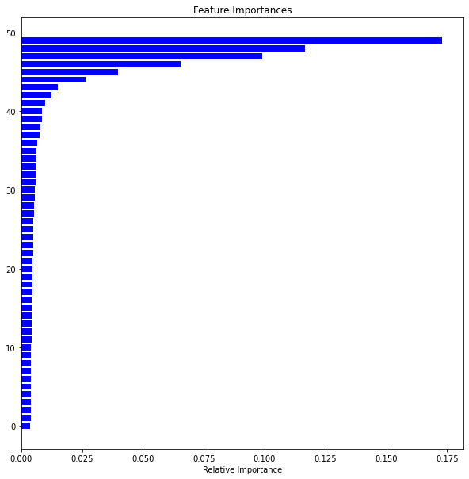

```python
# features = X_tr_train.columns   --- Which columns are picked in PCA, order of columns, we are not aware - So not plotting Features Names
importances = model_rfr.feature_importances_
indices = np.argsort(importances)[-50:]  # top 50 features
plt.title('Feature Importances')
plt.barh(range(len(indices)), importances[indices], color='b', align='center')
# plt.yticks(range(len(indices)), [features[i] for i in indices])
plt.xlabel('Relative Importance')
plt.show()
```

**#2 Apply XGBoost Techniques**

```python
import xgboost as xgb
```

```python
from sklearn.model_selection import RandomizedSearchCV
# model_xgbr = xgb.XGBRFRegressor()
```

Even with RandomizedSearchCV best estimator or params - XGBRFRegression is giving negative r2 score

```python
# params = {
#     'learning_rate':[0.05, 0.10, 0.15, 0.20, 0.25, 0.30],
#     'max_depth':[3, 4, 5, 6, 8, 10, 12, 15, 20, 25, 30, 35],
#     'min_child_weight':[1, 3, 5, 7, 9, 11, 13, 15],
#     'gamma':[0.0, 0.1, 0.2, 0.3, 0.4],
#     'colsample_bytree': [0.3, 0.4, 0.5, 0.7, 0.8],
#     'colsample_bylevel':[0.3, 0.4, 0.5, 0.7, 0.8],
#     'colsample_bynode':[0.3, 0.4, 0.5, 0.7, 0.8],
#     'n_estimators': [100, 150, 200, 250, 300],
#     'subsample':[0.3, 0.4, 0.5, 0.7, 0.8],
#     'base_score': [0.1, 0.2, 0.3, 0.5, 0.7, 0.9],
#     'booster': ['gblinear', 'gbtree', 'dart'],
#     'num_parallel_tree': [100, 150, 200, 250, 300, 350],
#     'random_state': [0, 5, 10, 15, 20],
#     'scale_pos_weight': [0.1, 0.3, 0.5, 0.7, 0.9]
# }
```

```python
# model_rsv = RandomizedSearchCV(model_xgbr, param_distributions=params, n_iter=5, scoring='r2', n_jobs=1, cv=5, verbose=3)
#model_rsv.fit(X_tr_train_pca,y_tr_train)
# model_rsv.best_estimator_
# model_rsv.best_params_
```

```python
# model_rsv = RandomizedSearchCV(model_xgbreg, param_distributions=params, n_iter=5, scoring='r2', n_jobs=1, cv=5, verbose=3)
# model_rsv.fit(X_tr_train_pca,y_tr_train)
```

**2.1 Apply XGBRFRegressor without RandomizedSearchCV suggested params**

```python
model_xgbr = xgb.XGBRFRegressor(booster='gblinear', learning_rate=1, n_estimators=550)
```

```python
model_xgbr.fit(X_tr_train_pca,y_tr_train)
```

```
XGBRFRegressor(base_score=0.5, booster='gblinear', colsample_bylevel=None,
               colsample_bynode=0.8, colsample_bytree=None, gamma=None,
               gpu_id=-1, importance_type='gain', interaction_constraints=None,
               learning_rate=1, max_delta_step=None, max_depth=None,
               min_child_weight=None, missing=nan, monotone_constraints=None,
               n_estimators=550, n_jobs=0, num_parallel_tree=None,
               objective='reg:squarederror', random_state=0, reg_alpha=0,
               reg_lambda=1e-05, scale_pos_weight=1, subsample=0.8,
               tree_method=None, validate_parameters=False, verbosity=None)
```

```python
y_pred_xgbr = model_xgbr.predict(X_tr_test_pca)
```

```python
r2_score(y_tr_test, y_pred_xgbr)
```

```
0.5801253507635217
```

**r2 scores for XGBRFRegressor with different Params combinations**

```python
#booster='gblinear', learning_rate=1, n_estimators=550 - 0.5801333198113591  --- Best Params

####Model is performing worse (getting -ve r2 score) if learning rate is less than 1####
```

**Importance of Features for XGBRFRegressor in the PCA applied X Train Data**

```python
# AttributeError: Feature importance is not defined for Booster type gblinear


# # features = X_tr_train.columns   --- Which columns are picked in PCA, order of columns, we are not aware - So not plotting Features Names
# importances = model_xgbr.feature_importances_
# indices = np.argsort(importances)[-50:]  # top 50 features
# plt.title('Feature Importances')
# plt.barh(range(len(indices)), importances[indices], color='b', align='center')
# # plt.yticks(range(len(indices)), [features[i] for i in indices])
# plt.xlabel('Relative Importance')
# plt.show()
```

**2.2 Apply XGBRegressor without RandomizedSearchCV suggested params**

```python
model_xgbreg = xgb.XGBRegressor(booster='gblinear', learning_rate=0.01, random_state=2, n_estimators=900)
```

```python
model_xgbreg.fit(X_tr_train_pca,y_tr_train)
```

```
XGBRegressor(base_score=0.5, booster='gblinear', colsample_bylevel=None,
             colsample_bynode=None, colsample_bytree=None, gamma=None,
             gpu_id=-1, importance_type='gain', interaction_constraints=None,
             learning_rate=0.01, max_delta_step=None, max_depth=None,
             min_child_weight=None, missing=nan, monotone_constraints=None,
             n_estimators=900, n_jobs=0, num_parallel_tree=None,
             objective='reg:squarederror', random_state=2, reg_alpha=0,
             reg_lambda=0, scale_pos_weight=1, subsample=None, tree_method=None,
             validate_parameters=False, verbosity=None)
```

```python
y_pred_xgbreg = model_xgbreg.predict(X_tr_test_pca)
```

```python
r2_score(y_tr_test, y_pred_xgbreg)
```

```
0.580113426895613
```

**r2 scores for XGBRegressor with different Params combinations**

```python
#booster='gbtree', learning_rate=0.01, random_state=2, n_estimators=650  - 0.55611427609201  --- Best Params for gbtree

####Descreasing from 800 for gbtree


# booster='gblinear', learning_rate=0.01, random_state=2, n_estimators=900  - 0.5801134272878716   ---- Best Params for gblinear

#####Even for larger increase r2 is increasing sligthlt after n_estimator=1000
```

**2.3 Apply XGBModel**

```python
import xgboost as xgb
```

```python
d_tr_train = xgb.DMatrix(data=X_tr_train_pca, label=y_tr_train)
```

```python
d_tr_test = xgb.DMatrix(data=X_tr_test_pca, label=y_tr_test)
```

```python
xgbparam = {'eta':0.1, 'objective':'reg:squarederror' }
```

```python
model_xgbmod = xgb.train(xgbparam, d_tr_train, num_boost_round=80)
```

```python
y_pred_xgbmod = model_xgbmod.predict(d_tr_test)
```

```python
r2_score(y_tr_test, y_pred_xgbmod)
```

```
0.5498822937983738
```

**r2 scores for XGBModel with different Params combinations**

```python
# 'eta':0.1, num_boost_round=41   --  0.5357897395464993

# 'eta':0.1, num_boost_round=50   --  0.5487014627426428

# 'eta':0.1, num_boost_round=80   --  0.5498822937983738    --- Best r2 score

# 'eta':0.05, num_boost_round=200  - 0.5452391643606216
```

#### **Verifying with Cross Validation Techniques**

**Applying PCA for Complete Train Data without Split**

```python
pca.fit(features_train_scaled)
pca.explained_variance_ratio_.size
```

```
145
```

**Complete Train Data Transform**

```python
features_train_pca = pca.transform(features_train_scaled)
features_train_pca.shape
```

```
(3924, 145)
```

```python
features_test_pca = pca.transform(features_test_scaled)
features_test_pca.shape
```

```
(4209, 145)
```

```python
from sklearn.model_selection import cross_val_score
```

**Cross Validation for Random Forest Regressor**

```python
score_rfr = cross_val_score(model_rfr, features_train_pca, target, cv=5)
print(score_rfr)
print("Avergae Score is", score_rfr.mean())
```

```
[0.52677099 0.53974165 0.50936533 0.49776623 0.55030036]
Avergae Score is 0.5247889139891366
```

**Cross Validation for Lasso Regression**

```python
score_lasso = cross_val_score(model_lasso, features_train_pca, target, cv=10)
print(score_lasso)
print("Avergae Score is", score_lasso.mean())
```

```
[0.65216063 0.60686744 0.58726428 0.59925705 0.60993274 0.47009923
 0.45956763 0.62917372 0.5466997  0.47382519]
Avergae Score is 0.563484760205291
```

**Cross Validation for XGBRFRegressor**

```python
score_xgbrf = cross_val_score(model_xgbr, features_train_pca, target, cv=10)
print(score_xgbrf)
print("Avergae Score is", score_xgbrf.mean())
```

```
[0.63289467 0.60235251 0.58036717 0.59732555 0.62567197 0.48609073
 0.54069294 0.61889123 0.6292286  0.6186795 ]
Avergae Score is 0.5932194872615244
```

**Cross Validation for XGBRegressor**

```python
score_xgbreg = cross_val_score(model_xgbreg, features_train_pca, target, cv=10)
print(score_xgbreg)
print("Avergae Score is", score_xgbreg.mean())
```

```
[-0.29939695  0.49298066  0.40307513  0.4364044   0.1873739  -0.29531965
  0.30564547  0.3590198  -0.39473727  0.1214718 ]
Avergae Score is 0.1316517298540869
```

**Cross Validation for XGBModel**

```python
from sklearn.model_selection import KFold
X = pd.DataFrame(features_train_pca)
Y = pd.DataFrame(target).reset_index(drop=True)
r2_score_arr = []
kf = KFold(n_splits=5, random_state=None)
kf.get_n_splits(features_train_pca, target)
for train_index,test_index in kf.split(features_train_pca, target):
#     print("Train Index:", train_index, "Validation", test_index)
    X1_train, X1_test = X.iloc[train_index], X.iloc[test_index]
    y1_train, y1_test = Y.iloc[train_index], Y.iloc[test_index]

    d_train = xgb.DMatrix(data=X1_train, label=y1_train['y'].values)
    d_test = xgb.DMatrix(data=X1_test, label=y1_test['y'].values)

    xgbparam = {'eta':0.1, 'objective':'reg:squarederror' }
    model_kfxgb = xgb.train(xgbparam, d_train, num_boost_round=80)
    y_pred_kfold = model_kfxgb.predict(d_test)
    r2score = r2_score(y1_test, y_pred_kfold)
    r2_score_arr.append(r2score)
np.array(r2_score_arr).mean()
```

```
0.5604749318243738
```

### **Step 6. Evaluate Model**

```python
from sklearn.metrics import r2_score
from sklearn.metrics import mean_squared_error
```

**Linear Regression Algorithm Metrics Evaluation - With Test Train Split**

```python
print("R2score is", r2_score(y_tr_test, y_pred_lr))
print("RMSE is", np.sqrt(mean_squared_error(y_tr_test, y_pred_lr)))
```

```
R2score is 0.5801537981789575
RMSE is 7.360733591629869
```

**Lasso Regression Algorithm Metrics Evaluation - With Test Train Split vs KFold CV**

```python
print("R2score is", r2_score(y_tr_test, y_pred_lasso))
print("RMSE is", np.sqrt(mean_squared_error(y_tr_test, y_pred_lasso)))
```

```
R2score is 0.5815549312956898
RMSE is 7.34844101101138
```

```python
print("R2 score with KFold CV is", score_lasso.mean())
```

```
R2 score with KFold CV is 0.563484760205291
```

**K Nearest Neighbors Regressor Algorithm Metrics Evaluation - With Train Test Split**

```python
print("R2score is", r2_score(y_tr_test, y_pred_knn))
print("RMSE is", np.sqrt(mean_squared_error(y_tr_test, y_pred_knn)))
```

```
R2score is 0.45545247129565414
RMSE is 8.382892191079792
```

**Decision Tree Regressor Algorithm Metrics Evaluation - With Train Test Split**

```python
print("R2score is", r2_score(y_tr_test, y_pred_dtr))
print("RMSE is", np.sqrt(mean_squared_error(y_tr_test, y_pred_dtr)))
```

```
R2score is -0.020689970825636506
RMSE is 11.476855374689661
```

**Random Forest Ensemble Alogorithm Metrics Evaluation - With Train Test Split vs KFold CV**

```python
print("R2 score with Train Test Split is", r2_score(y_tr_test, y_pred_rfr))
print("RMSE is", np.sqrt(mean_squared_error(y_tr_test, y_pred_rfr)))
```

```
R2 score with Train Test Split is 0.5274245940408445
RMSE is 7.809289864510982
```

```python
print("R2 score with KFold CV is", score_rfr.mean())
```

```
R2 score with KFold CV is 0.5247889139891366
```

**XGBRFRegressor Metrics Evaluation - With Train Test Split vs KFold CV**

```python
print("R2 score with Train Test Split is",r2_score(y_tr_test, y_pred_xgbr))
print("RMSE is", np.sqrt(mean_squared_error(y_tr_test, y_pred_xgbr)))
```

```
R2 score with Train Test Split is 0.5801253507635217
RMSE is 7.360982957110185
```

```python
print("R2 score with KFold CV is", score_xgbrf.mean())
```

```
R2 score with KFold CV is 0.5932194872615244
```

**XGBRegressor Metrics Evaluation - With Train Test Split vs KFold CV**

```python
print("R2 score with Train Test Split is", r2_score(y_tr_test, y_pred_xgbreg))
print("RMSE is", np.sqrt(mean_squared_error(y_tr_test, y_pred_xgbreg)))
```

```
R2 score with Train Test Split is 0.580113426895613
RMSE is 7.361087477311012
```

```python
print("R2 score with KFold CV is",score_xgbreg.mean())
```

```
R2 score with KFold CV is 0.1316517298540869
```

**XGBoost Metrics Evaluation - With Train Test Split vs KFold CV**

```python
print("R2 score with Train Test Split is", r2_score(y_tr_test, y_pred_xgbmod))
print("RMSE is", np.sqrt(mean_squared_error(y_tr_test, y_pred_xgbmod)))
```

```
R2 score with Train Test Split is 0.5498822937983738
RMSE is 7.621475075766128
```

```python
print("R2 score with KFold CV is", np.array(r2_score_arr).mean())
```

```
R2 score with KFold CV is 0.5604749318243738
```

Prediction with XGBoost

```python
d_train_matx = xgb.DMatrix(data=features_train_pca, label=target)
d_test_matx = xgb.DMatrix(data=features_test_pca)
```

```python
xgbparam = {'eta':0.1, 'objective':'reg:squarederror'}
```

```python
model_xgb_compl = xgb.train(xgbparam, d_train_matx, num_boost_round=80)
```

```python
y_pred_test_vals = model_xgb_compl.predict(d_test_matx)
```

```python
y_pred_test_vals
```

```
array([ 84.9248 , 106.31748,  84.7337 , ...,  89.16706, 109.81949,
        93.89433], dtype=float32)
```

Prediction with XGBRFRegressor

```python
model_xgbrf_compl = xgb.XGBRFRegressor(booster='gblinear', learning_rate=1, n_estimators=550)
```

```python
model_xgbrf_compl.fit(features_train_pca, target)
```

```
XGBRFRegressor(base_score=0.5, booster='gblinear', colsample_bylevel=None,
               colsample_bynode=0.8, colsample_bytree=None, gamma=None,
               gpu_id=-1, importance_type='gain', interaction_constraints=None,
               learning_rate=1, max_delta_step=None, max_depth=None,
               min_child_weight=None, missing=nan, monotone_constraints=None,
               n_estimators=550, n_jobs=0, num_parallel_tree=None,
               objective='reg:squarederror', random_state=0, reg_alpha=0,
               reg_lambda=1e-05, scale_pos_weight=1, subsample=0.8,
               tree_method=None, validate_parameters=False, verbosity=None)
```

```python
y_pred_test_vals_xgbrf = model_xgbrf_compl.predict(features_test_pca)
```

```python
y_pred_test_vals_xgbrf
```

```
array([ 99.50013 , 116.646935, 101.892395, ...,  92.42944 , 111.85654 ,
        94.21398 ], dtype=float32)
```